# Figures: 2008-2015 averages by county

asmtry

# Setup

This worksheet leans heavily on `tidyverse` packages.

## Import data

`cdl.table` contains relations between crops, their index number in the Cropland Data Layer, and the corresponding name and index number in the FAO Indicative Crop Classification (ICC 1.1).

`roi.table` contains relations from the regions of interest used to aggregrate the WF, PPT, and CWU calculations performed in steps 8-10. Here, the relation is the attribute table from a shapefile of California county political boundaries. Attributes include: county index, name, and corresponding DWR hydrologic region.

`ca.counties` contains the shapefile, on which `roi.table` is based.

`ca.hr` contains the shapefile of DWR hydrologic regions, for California.

`wf.master.wyear` contains annual sums of cwr, ppt, etc, wf, and harvested tons/acres/USD aggregrated by crop, county, and water year. It only includes the counties that have corresponding entries in the County Ag Comissioners (CAC) annual yield reports. Counties that had modeled ag production, without an accompanying entry in the CAC annual reports were omitted.

`wf.master.cyear` contains the above, except aggregrated by calendar year (instead of water year). This data set includes the extra year of 2007.

`yield.master` contains all of the statistics reported by the CAC annual reports (production tons, harvested acres, value in USD), for the modeled crops.

## Create some functions for commonly used summary statistics

Typially in a boxplot, outliers are marked as values that fall outside of 1.5 times the interquartile range avove and below the 25% and 75% quantiles. `is_extreme()` is a function that we define below, that applys the same criteria and returns TRUE if the value is a suspected outlier/extreme falue, and false otherwise.

```r
is_extreme <- function(series) {
  #' Tags values in a series according to whether or not they would appear as oulier points
  #` in a Tukey boxplot (values that lie outside of the H-spread.)
  #` Specifically, these are values that are less or greater than the 1st and 3rd quartiles
  #` plus 1.5 times the interquartile range.
  #' @param series Vector of type numeric (int or double)
  #' @return Vector of type logical, TRUE if the value is an outlier, FALSE if it is not
  return(series < (quantile(series, 0.25) - (1.5 * IQR(series)) ) | series > (quantile(series, 0.75) + (1.5 * IQR(series)) ))
}
```

## Clean erronious observations

Here, we clean obviously erronious observations.

I think the 2009 Riverside CAC survey severly under-reports the “Oats” category to the point that it makes the “Oats” water footprint blow up (several orders of magnitude higher than baseline, see the by-year summary notebook).

```r
wf.master.wyear <- wf.master.wyear %>%
  filter(!(`cdl.name` == "Oats" & `County` == "Riverside" & `Year` == 2009))
```

# C1: Average statewide water demand *for all* years, by county

Here, we sum all daily volumes of cwr, ppt, et, and wf by county, over each calendar and water year. Then, we average all of the yearly sums, to produce an “average year” value, for each parameter.

```r
wf.master.allcounty.cyear <- wf.master.cyear %>%
  group_by(roi.index, County, Year) %>%
  summarize_at(vars(cwr, ppt, et.b, et.g, wf.b, wf.g), funs(sum(., na.rm = TRUE))) %>%
  group_by(roi.index, County) %>%
  summarize_at(vars(cwr, ppt, et.b, et.g, wf.b, wf.g), funs(avg = "mean")) %>%
  left_join(roi.table %>% select(NUM,`HR_NAME`),
            by = c("roi.index" = "NUM")) %>%
  ungroup() %>%         # I'm not sure what to think about the expicit `ungroup()`
  `attr<-`("year_type", "calendar") %>%
  `attr<-`("summary_type", "total")

wf.master.allcounty.wyear <- wf.master.wyear %>%
  group_by(roi.index, County, Year) %>%
  summarize_at(vars(cwr, ppt, et.b, et.g, wf.b, wf.g), funs(sum(., na.rm = TRUE))) %>%
  group_by(roi.index, County) %>%
  summarize_at(vars(cwr, ppt, et.b, et.g, wf.b, wf.g), funs(avg = "mean")) %>%
  left_join(roi.table %>% select(NUM,`HR_NAME`),
            by = c("roi.index" = "NUM")) %>%
  ungroup() %>%
  `attr<-`("year_type", "water") %>%
  `attr<-`("summary_type", "total")
```

# P1: Average Blue WF vs Green WF, county-wise

Depending on the number of counties in your corpus, it may or may not make sense to visualize all counties simultaneously. Here, there are a handfull of counties at the extreme end of blue/green WF, that make it difficult to distinguish between the other counties

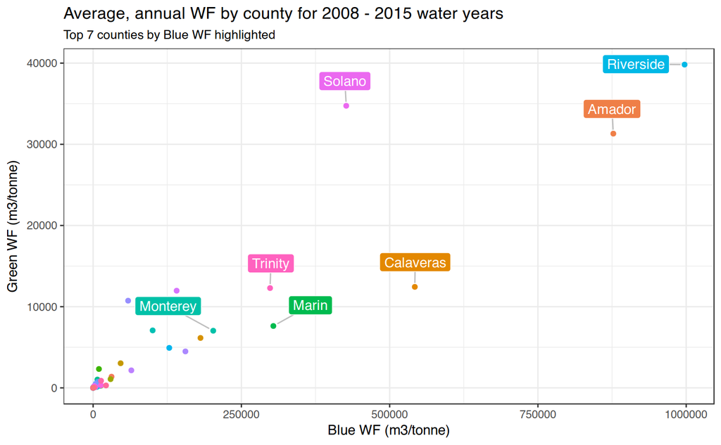

```r
# local({
  # wfb_vs_wfg <-
    wf.master.allcounty.wyear %>%
    # Mark top 3 wf.b_avg counties as outlier and tag either by County or NA
    left_join(wf.master.allcounty.wyear %>%
                top_n(7, wf.b_avg) %>%
                select(`roi.index`, outlier = `County`),
              by = "roi.index") %>%
    ggplot() +
    geom_point(mapping = aes(x = wf.b_avg, y = wf.g_avg, color = County)) +
    geom_label_repel(mapping = aes(x = wf.b_avg, y = wf.g_avg, label = outlier, fill = County),
                   color = "white", segment.color = 'grey', box.padding = unit(0.35, "lines"),
                   point.padding = unit(0.5, "lines"), na.rm = TRUE, nudge_y = 51) +
    guides(color = "none", fill = "none") +
    labs(title = "Average, annual WF by county for 2008 - 2015 water years",
         subtitle = "Top 7 counties by Blue WF highlighted",
         x = "Blue WF (m3/tonne)", y = "Green WF (m3/tonne)")
```

[figure not shown]

```r
  # etb_vs_etg <-
    wf.master.allcounty.wyear %>%
    # Mark top 3 et.b_avg counties as outlier and tag either by County or NA
    left_join(wf.master.allcounty.wyear %>%
                top_n(3, et.b_avg) %>%
                select(`roi.index`, outlier = `County`),
              by = "roi.index") %>%
    ggplot() +
    geom_point(mapping = aes(x = et.b_avg, y = et.g_avg, color = County)) +
    geom_label_repel(mapping = aes(x = et.b_avg, y = et.g_avg, label = outlier, fill = County),
                   color = "white", segment.color = 'grey', box.padding = unit(0.35, "lines"),
                   point.padding = unit(0.5, "lines"), na.rm = TRUE, nudge_y = 51) +
    guides(color = "none", fill = "none") +
    labs(title = "Average, annual ET by county for 2008 - 2015 water years",
         subtitle = "Top 3 counties by Green ET highlighted",
         x = "Blue ET (m3)", y = "Green ET (m3)")
```

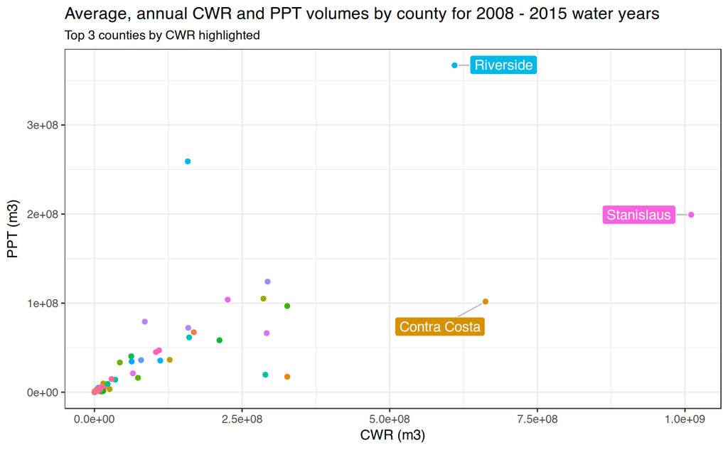

```r
  # cwr_vs_ppt <-
    wf.master.allcounty.wyear %>%
    # Mark top 3 et.b_avg counties as outlier and tag either by County or NA
    left_join(wf.master.allcounty.wyear %>%
                top_n(3, cwr_avg) %>%
                select(`roi.index`, outlier = `County`),
              by = "roi.index") %>%
    ggplot() +
    geom_point(mapping = aes(x = cwr_avg, y = ppt_avg, color = County)) +
    geom_label_repel(mapping = aes(x = cwr_avg, y = ppt_avg, label = outlier, fill = County),
                   color = "white", segment.color = 'grey', box.padding = unit(0.35, "lines"),
                   point.padding = unit(0.5, "lines"), na.rm = TRUE, nudge_y = 51) +
    guides(color = "none", fill = "none") +
    labs(title = "Average, annual CWR and PPT volumes by county for 2008 - 2015 water years",
         subtitle = "Top 3 counties by CWR highlighted",
         x = "CWR (m3)", y = "PPT (m3)")
```

```r
  #plot_grid(arrangeGrob(wfb_vs_wfg, etb_vs_etg, ncol=1), nrow = 1)
# })
```

# P2: Average Blue WF vs Green WF, county-wise w/ hydrologic regions

We can also group counties by a classification based on location. Here, we are using regional classifications that align with the major drainage basins of California. These basins used for a variety of planning purposes and DWR programs, including the CA Water plan.

There are other planning regions used by the DWR including:

`Planning Areas`, which are subsets of the Hydrologic Regions, used for data collection and planning purposes under the CA Water Plan.

`Detailed Analysis Units (DAUs)`, which are supsets of the Planning Areas, used for data colection and planning purposes under the CA Water plan.

On the right, we use a log/log plot in order to examine the structure of counties on the low-end of WF, since a few, high-WF counties greately influence the scale.

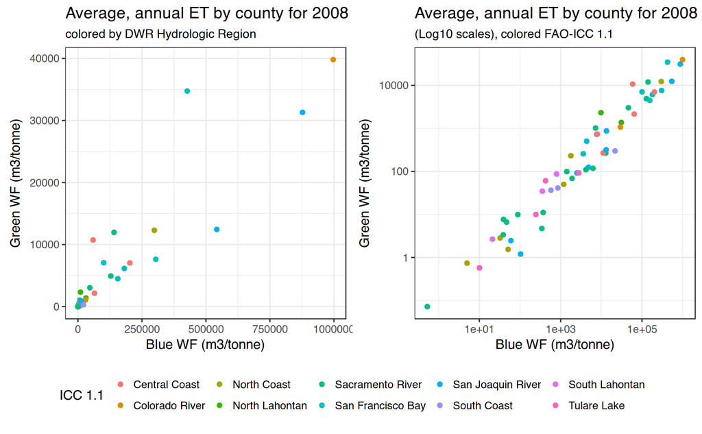

```r
local({
  wfb_vs_wfg_icc <- wf.master.allcounty.wyear %>%
    ggplot() +
    geom_point(mapping = aes(x = wf.b_avg, y = wf.g_avg, color = HR_NAME)) +
    labs(title = "Average, annual ET by county for 2008 - 2015 water years",
         subtitle = "colored by DWR Hydrologic Region",
         x = "Blue WF (m3/tonne)", y = "Green WF (m3/tonne)", color = "ICC 1.1") +
    theme(legend.position = "none")

  wfb_vs_wfg_icc_log <- wf.master.allcounty.wyear %>%
    ggplot() +
    geom_point(mapping = aes(x = wf.b_avg, y = wf.g_avg, color = HR_NAME)) +
    scale_x_log10() +
    scale_y_log10() +
    labs(title = "Average, annual ET by county for 2008 - 2015 water years",
         subtitle = "(Log10 scales), colored FAO-ICC 1.1",
         x = "Blue WF (m3/tonne)", y = "Green WF (m3/tonne)", color = "ICC 1.1") +
    theme(legend.position = "none")

  l1 <- get_legend(wfb_vs_wfg_icc + guides(fill = guide_legend()) + theme(legend.position="bottom"))
  plot_grid(arrangeGrob(wfb_vs_wfg_icc, wfb_vs_wfg_icc_log, ncol=2), l1, ncol = 1, rel_heights = c(1, .2))
})
```

# P3: Average Blue WF vs Green WF, county-wise w/ FAO groups and convex hull

We can add convex hulls to see if there is any clustering of counties by the WF or ET metrics, by FAO-ICC group. Use `ggalt::geom_encircle()` for convex hulls.

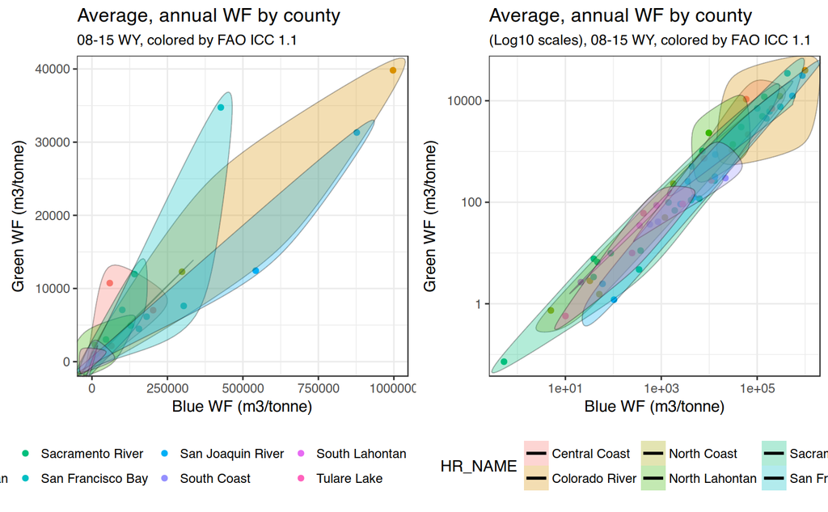

```r
local({
  wfb_vs_wfg_icc <- wf.master.allcounty.wyear %>%
    ggplot() +
    geom_point(mapping = aes(x = wf.b_avg, y = wf.g_avg, color = HR_NAME)) +
    geom_encircle(mapping = aes(x = wf.b_avg, y = wf.g_avg, fill = HR_NAME),alpha=0.3) +
    labs(title = "Average, annual WF by county",
         subtitle = "08-15 WY, colored by FAO ICC 1.1",
         x = "Blue WF (m3/tonne)", y = "Green WF (m3/tonne)", color = "FAO-ICC 1.1") +
    theme(legend.position = "none")

  wfb_vs_wfg_icc_log <- wf.master.allcounty.wyear %>%
    ggplot() +
    geom_point(mapping = aes(x = wf.b_avg, y = wf.g_avg, color = HR_NAME)) +
    geom_encircle(mapping = aes(x = wf.b_avg, y = wf.g_avg, fill = HR_NAME),alpha=0.3) +
    scale_x_log10() +
    scale_y_log10() +
    labs(title = "Average, annual WF by county",
         subtitle = "(Log10 scales), 08-15 WY, colored by FAO ICC 1.1",
         x = "Blue WF (m3/tonne)", y = "Green WF (m3/tonne)", color = "FAO-ICC 1.1") +
    theme(legend.position = "none")

  l1 <- get_legend(wfb_vs_wfg_icc + guides(fill = guide_legend()) + theme(legend.position="bottom"))
  plot_grid(arrangeGrob(wfb_vs_wfg_icc, wfb_vs_wfg_icc_log, ncol=2), l1, ncol = 1, rel_heights = c(1, .2))
})
```

Still not particularly informative. There seems to be a strong 1:1 relationship between Blue WF and Green WF, which intuitively does not make very much sense. California grows lots of foods in regions that have nearly zero rainfall (Imperial county comes to mind.) I’d have to think about what is going on here.

## P3.5 ET and CWU vs PPT

Let’s take a look at overall county water demand vs ppt, and blue/green ET.

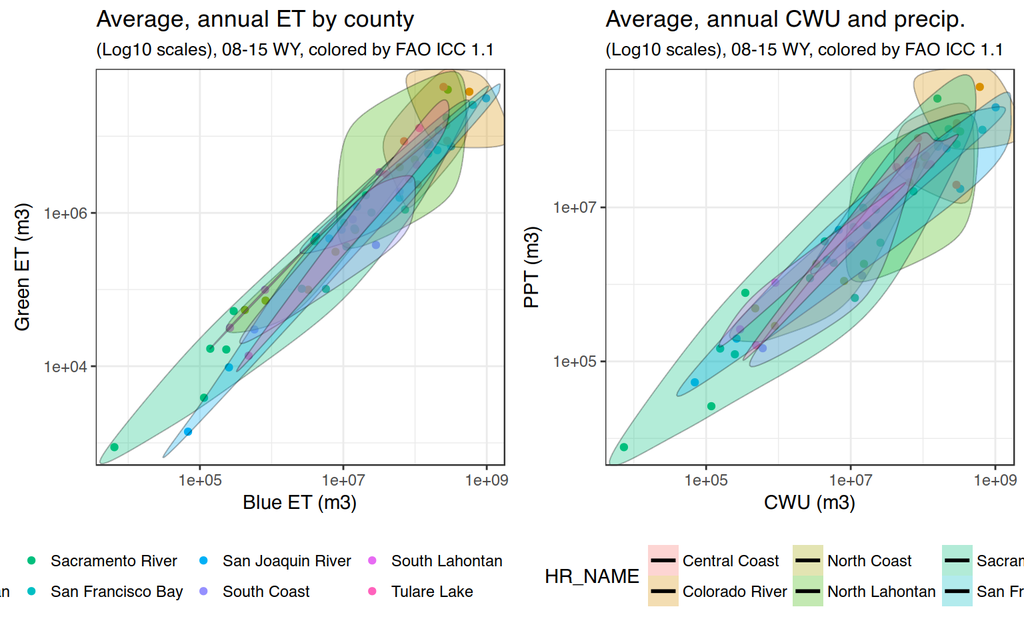

```r
local({
  etb_vs_etg_icc_log <- wf.master.allcounty.wyear %>%
    ggplot() +
    geom_point(mapping = aes(x = et.b_avg, y = et.g_avg, color = HR_NAME)) +
    geom_encircle(mapping = aes(x = et.b_avg, y = et.g_avg, fill = HR_NAME),alpha=0.3) +
    scale_x_log10() +
    scale_y_log10() +
    labs(title = "Average, annual ET by county",
         subtitle = "(Log10 scales), 08-15 WY, colored by FAO ICC 1.1",
         x = "Blue ET (m3)", y = "Green ET (m3)", color = "FAO-ICC 1.1") +
    theme(legend.position = "none")

  cwu_vs_ppt_icc_log <- wf.master.allcounty.wyear %>%
    ggplot() +
    geom_point(mapping = aes(x = cwr_avg, y = ppt_avg, color = HR_NAME)) +
    geom_encircle(mapping = aes(x = cwr_avg, y = ppt_avg, fill = HR_NAME),alpha=0.3) +
    scale_x_log10() +
    scale_y_log10() +
    guides(color = "none") +
    labs(title = "Average, annual CWU and precip.",
         subtitle = "(Log10 scales), 08-15 WY, colored by FAO ICC 1.1",
         x = "CWU (m3)", y = "PPT (m3)", color = "FAO-ICC 1.1") +
    theme(legend.position = "none")

  l1 <- get_legend(etb_vs_etg_icc_log + guides(fill = guide_legend()) + theme(legend.position="bottom"))
  plot_grid(arrangeGrob(etb_vs_etg_icc_log, cwu_vs_ppt_icc_log, ncol=2), l1, ncol = 1, rel_heights = c(1, .2))
})
```

Since Green WF is directly related to precipitation, and Blue WF is directly related to the crop water requirement we would expect the plots to look similar, and in fact they do look like affine transformations of each other.

# P4: Average Blue WF vs Green WF vs CWU, county-wise

What if we maintain the same groupings, but color (and size) by crop water requirement instead?

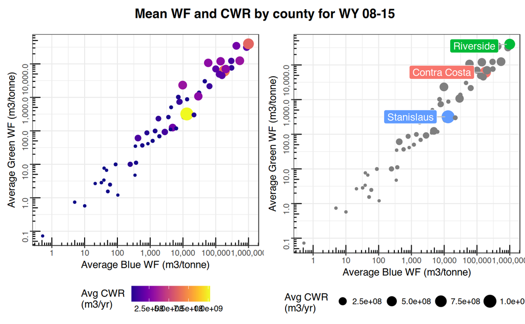

```r
local({
  wfb_wgf_cwu <- wf.master.allcounty.wyear %>%
  ggplot() +
  geom_point(mapping = aes(x = wf.b_avg, y = wf.g_avg, size = cwr_avg, color = cwr_avg)) +
  scale_x_continuous(trans = "log10", labels = scales::comma,
                     breaks = scales::trans_breaks("log10", function(x) 10^x)) +
  scale_y_continuous(trans = "log10", labels = scales::comma,
                     breaks = scales::trans_breaks("log10", function(x) 10^x)) +
  annotation_logticks() +
  scale_color_viridis(option = "plasma") +
  labs(x = "Average Blue WF (m3/tonne)", y = "Average Green WF (m3/tonne)",
       color = "Avg CWR \n(m3/yr)", size = "Avg CWR \n(m3/yr)") +
  guides(size = "none") +
  theme(axis.text.y = element_text(angle = 90), legend.position = "bottom")

  wfb_wgf_cwu_icc <- wf.master.allcounty.wyear %>%
  mutate(outlier = ifelse(is_extreme(cwr_avg), County, NA)) %>%
  mutate(funs(factor), outlier) %>%
  ggplot() +
  geom_point(mapping = aes(x = wf.b_avg, y = wf.g_avg, size = cwr_avg, color = outlier)) +
  geom_label_repel(mapping = aes(x = wf.b_avg, y = wf.g_avg, label = outlier, fill = outlier),
                   color = "white", segment.color = 'grey', box.padding = unit(0.35, "lines"),
                   point.padding = unit(0.5, "lines"), na.rm = TRUE, nudge_x = -1)  +
  scale_x_continuous(trans = "log10", labels = scales::comma,
                     breaks = scales::trans_breaks("log10", function(x) 10^x)) +
  scale_y_continuous(trans = "log10", labels = scales::comma,
                     breaks = scales::trans_breaks("log10", function(x) 10^x)) +
  annotation_logticks() +
  labs(x = "Average Blue WF (m3/tonne)", y = "Average Green WF (m3/tonne)",
       color = "Extreme \ncounties \n(for CWR)", size = "Avg CWR \n(m3/yr)") +
  guides(fill = "none", color = "none") +
  theme(axis.text.y = element_text(angle = 90), legend.position = "bottom")

  t1 <- ggdraw() + draw_label("Mean WF and CWR by county for WY 08-15", fontface='bold')
  plot_grid(t1, arrangeGrob(wfb_wgf_cwu, wfb_wgf_cwu_icc, nrow=1), ncol=1, rel_heights=c(0.1, 1))

})
```

# P5: Treeplot, Blue WF vs CWU, county-wise

The contrast between WF and CWU is very apparent when visualized with a treemap. You can use the `treemapify` extension to `ggplot2` to draw these treemaps. As of June 2017, `treemapify` is not found in CRAN, and must be installed through `devtools` from github ([link][https://github.com/wilkox/treemapify].

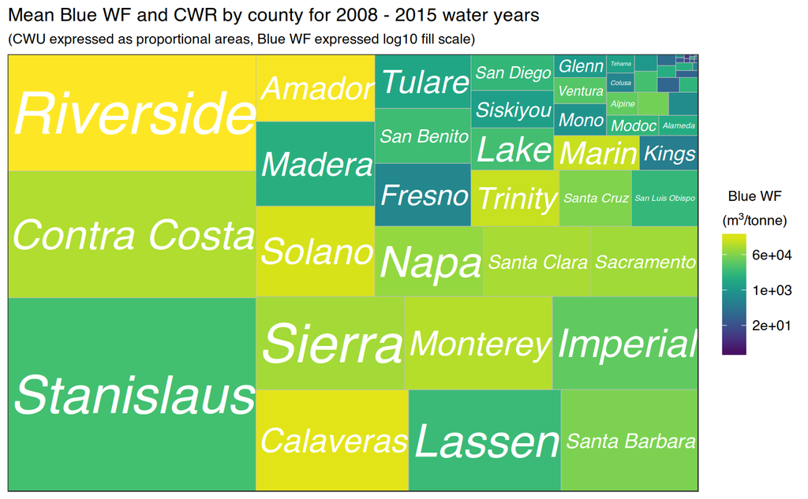

```r
wf.master.allcounty.wyear %>%
  ggplot(mapping = aes(area = cwr_avg, fill = wf.b_avg, label = County)) +
  geom_treemap() +
  geom_treemap_text(fontface = "italic", colour = "white",
                    place = "centre", grow = TRUE) +
  scale_fill_viridis(trans = "log", option = "viridis", labels = function(x) format(signif(x,1)/1, scientific = TRUE)) +
  labs(title = "Mean Blue WF and CWR by county for 2008 - 2015 water years",
       subtitle = "(CWU expressed as proportional areas, Blue WF expressed log10 fill scale)",
       fill = bquote(atop("Blue WF", "("*m^3*"/tonne)"))) +
  theme(legend.text=element_text(size=10),
        legend.title=element_text(size=10))
```

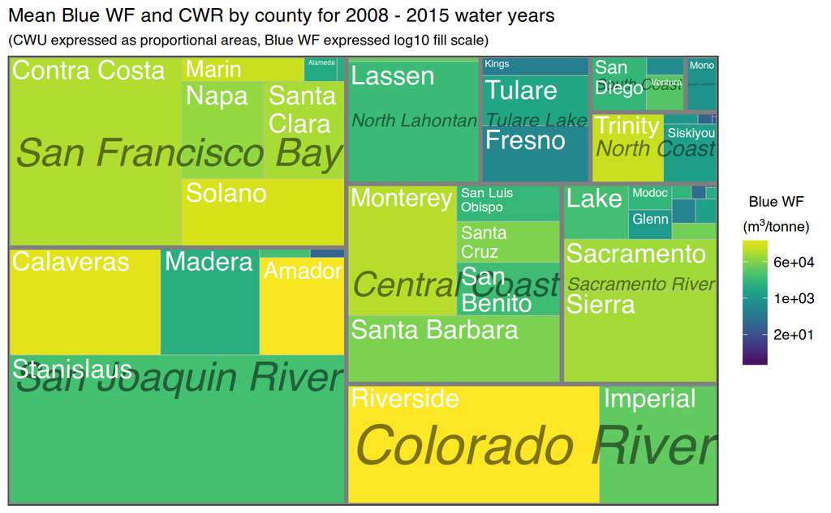

```r
wf.master.allcounty.wyear %>%
  ggplot(mapping = aes(area = cwr_avg, fill = wf.b_avg,
                     label = County, subgroup = HR_NAME)) +
  geom_treemap() +
  geom_treemap_subgroup_border() +
  geom_treemap_subgroup_text(place = "centre", grow = T, alpha = 0.5,
                             colour = "black", fontface = "italic", min.size = 0) +
  geom_treemap_text(colour = "white", place = "topleft", reflow = T) +
  scale_fill_viridis(trans = "log", option = "viridis", labels = function(x) format(signif(x,1)/1, scientific = TRUE)) +
  labs(title = "Mean Blue WF and CWR by county for 2008 - 2015 water years",
       subtitle = "(CWU expressed as proportional areas, Blue WF expressed log10 fill scale)",
       fill = bquote(atop("Blue WF", "("*m^3*"/tonne)"))) +
  theme(legend.text=element_text(size=10),
        legend.title=element_text(size=10))
```

```r
  # l1 <- get_legend(bwf_cwu + guides(fill = guide_legend()) + theme(legend.position="bottom"))
  # plot_grid(arrangeGrob(bwf_cwu, bwf_cwu_icc, ncol=2), l1, ncol = 1, rel_heights = c(1, .2))
```

# T1: Table, Average CWU (AF and TAF)

The following is a tabulation the average CWU in acre-feet (AF) and thousand-acre-feet (TAF) for comparison to other tallies of statewide water use. Be aware that these values represent the *average* of yearly sums for each October-September period, from 2008-2015.

```r
# For displaying hundreds w/o scientific notation in html table
options("scipen"=100, "digits"=4)
# For fancy html tables
options(knitr.table.format = "html")

cwu.sum <- wf.master.allcounty.wyear %>%
  select(county = County, cu.m = cwr_avg) %>%
  mutate(AF = (cu.m * 0.0008107)) %>%
  mutate(TAF = (AF / 1000))
cwu.sum %>%
  bind_rows(cbind(county = "Total",
                  cwu.sum %>%
                    summarize_at(vars(cu.m, AF, TAF), funs(sum)))) %>%
  kable() %>%
  kable_styling("striped", full_width = F) %>%
  row_spec(nrow(cwu.sum)+1, bold = T)
```

| county | cu.m | AF | TAF |
| --- | --- | --- | --- |
| Alameda | 16769074 | 13594.688 | 13.5947 |
| Alpine | 15236634 | 12352.339 | 12.3523 |
| Amador | 168244587 | 136395.887 | 136.3959 |
| Butte | 348184 | 282.272 | 0.2823 |
| Calaveras | 326517457 | 264707.702 | 264.7077 |
| Colusa | 11395945 | 9238.693 | 9.2387 |
| Contra Costa | 662187081 | 536835.066 | 536.8351 |
| Del Norte | 8091353 | 6559.660 | 6.5597 |
| El Dorado | 14875546 | 12059.605 | 12.0596 |
| Fresno | 127427142 | 103305.184 | 103.3052 |
| Glenn | 25717188 | 20848.924 | 20.8489 |
| Humboldt | 895117 | 725.671 | 0.7257 |
| Imperial | 286116486 | 231954.635 | 231.9546 |
| Inyo | 294934 | 239.103 | 0.2391 |
| Kern | 491734 | 398.649 | 0.3986 |
| Kings | 42905253 | 34783.288 | 34.7833 |
| Lake | 73685643 | 59736.950 | 59.7370 |
| Lassen | 326435526 | 264641.281 | 264.6413 |
| Los Angeles | 14376003 | 11654.626 | 11.6546 |
| Madera | 211658037 | 171591.171 | 171.5912 |
| Marin | 62287615 | 50496.569 | 50.4966 |
| Mariposa | 263676 | 213.762 | 0.2138 |
| Mendocino | 3338804 | 2706.768 | 2.7068 |
| Merced | 69703 | 56.508 | 0.0565 |
| Modoc | 22346876 | 18116.612 | 18.1166 |
| Mono | 35270224 | 28593.570 | 28.5936 |
| Monterey | 289434333 | 234644.414 | 234.6444 |
| Napa | 160361862 | 130005.361 | 130.0054 |
| Nevada | 5816072 | 4715.090 | 4.7151 |
| Orange | 606222 | 491.464 | 0.4915 |
| Placer | 118049 | 95.702 | 0.0957 |
| Plumas | 7295 | 5.914 | 0.0059 |
| Riverside | 609825623 | 494385.633 | 494.3856 |
| Sacramento | 158058469 | 128138.001 | 128.1380 |
| San Benito | 111424122 | 90331.536 | 90.3315 |
| San Bernardino | 908935 | 736.873 | 0.7369 |
| San Diego | 63013480 | 51085.029 | 51.0850 |
| San Joaquin | 6843215 | 5547.794 | 5.5478 |
| San Luis Obispo | 78949526 | 64004.380 | 64.0044 |
| San Mateo | 4666141 | 3782.840 | 3.7828 |
| Santa Barbara | 293203038 | 237699.703 | 237.6997 |
| Santa Clara | 158778562 | 128721.781 | 128.7218 |
| Santa Cruz | 85247417 | 69110.081 | 69.1101 |
| Shasta | 2734944 | 2217.219 | 2.2172 |
| Sierra | 291571253 | 236376.815 | 236.3768 |
| Siskiyou | 65126996 | 52798.456 | 52.7985 |
| Solano | 225681435 | 182959.939 | 182.9599 |
| Sonoma | 477615 | 387.202 | 0.3872 |
| Stanislaus | 1010548916 | 819252.006 | 819.2520 |
| Sutter | 249670 | 202.407 | 0.2024 |
| Tehama | 10987110 | 8907.250 | 8.9073 |
| Trinity | 104136257 | 84423.263 | 84.4233 |
| Tulare | 109252611 | 88571.091 | 88.5711 |
| Tuolumne | 10058741 | 8154.621 | 8.1546 |
| Ventura | 28885374 | 23417.373 | 23.4174 |
| Yolo | 4371378 | 3543.876 | 3.5439 |
| Yuba | 156364 | 126.764 | 0.1268 |
| Total | 6348746843 | 5146929.066 | 5146.9291 |

## T1.5 Sortable table

What follows is a sortable, interactive table (HTML output only):

```r
datatable(cwu.sum, class = 'cell-border stripe')
```

|  | county | cu.m | AF | TAF |
| --- | --- | --- | --- | --- |
| 1 | Alameda | 16769073.7010587 | 13594.6880494483 | 13.5946880494483 |
| 2 | Alpine | 15236634.3225 | 12352.3394452508 | 12.3523394452508 |
| 3 | Amador | 168244587.094005 | 136395.88675711 | 136.39588675711 |
| 4 | Butte | 348183.539565 | 282.272395525345 | 0.282272395525345 |
| 5 | Calaveras | 326517456.96969 | 264707.702365328 | 264.707702365328 |
| 6 | Colusa | 11395945.2001243 | 9238.69277374076 | 9.23869277374076 |
| 7 | Contra Costa | 662187080.880956 | 536835.066470191 | 536.835066470191 |
| 8 | Del Norte | 8091353.1405 | 6559.65999100335 | 6.55965999100335 |
| 9 | El Dorado | 14875546.3773075 | 12059.6054480832 | 12.0596054480832 |
| 10 | Fresno | 127427141.638226 | 103305.18372611 | 103.30518372611 |

[output cut: 47 more lines]